# Homework #5

**See Canvas for HW #5 assignment due date**. Complete all of the following problems. Ideally, the theoretical problems should be answered in a Markdown cell directly underneath the question. If you don't know LaTex/Markdown, you may submit separate handwritten solutions to the theoretical problems. Please do not turn in messy work. Computational problems should be completed in this notebook (using the R kernel is preferred). Computational questions may require code, plots, analysis, interpretation, etc. Working in small groups is allowed, but it is important that you make an effort to master the material and hand in your own work.

# This week, there won't be any "theory" homework. Please use that time to work on your project proposal.

# Problem B.1: Model Selection Criterion (55 points)

In this lesson, we will perform both the full and partial F-tests in R.

Recall again, the Amazon book data. The data consists of data on $n = 325$ books and includes measurements of:

- `aprice`: The price listed on Amazon (dollars)
- `lprice`: The book's list price (dollars)
- `weight`: The book's weight (ounces)
- `pages`: The number of pages in the book
- `height`: The book's height (inches)
- `width`: The book's width (inches)
- `thick`: The thickness of the book (inches)
- `cover`: Whether the book is a hard cover of paperback.
- And other variables...

Before we do any model selection, we'll repeat the data cleaning methods from the previous lesson on this dataset. For all tests in this lesson, let $\alpha = 0.05$.

```r
# This cell loads the required packages
library(testthat)
library(tidyverse)
library(car)
```

```r
library(RCurl) #a package that includes the function getURL(), which allows for reading data from github.
library(ggplot2)
url = getURL(paste0("https://raw.githubusercontent.com/bzaharatos/",
                    "-Statistical-Modeling-for-Data-Science-Applications/",
                    "master/Modern%20Regression%20Analysis%20/Datasets/amazon.txt"))
amazon = read.csv(text = url, sep = "\t")
df = data.frame(aprice = amazon$Amazon.Price, lprice = as.numeric(amazon$List.Price),
                pages = amazon$NumPages, width = amazon$Width, weight = amazon$Weight..oz,
                height = amazon$Height, thick = amazon$Thick, cover = amazon$Hard..Paper)

df$lprice[which(is.na(df$lprice))] = mean(df$lprice, na.rm = TRUE)
df$weight[which(is.na(df$weight))] = mean(df$weight, na.rm = TRUE)
df$pages[which(is.na(df$pages))] = mean(df$pages, na.rm = TRUE)
df$height[which(is.na(df$height))] = mean(df$height, na.rm = TRUE)
df$width[which(is.na(df$width))] = mean(df$width, na.rm = TRUE)
df$thick[which(is.na(df$thick))] = mean(df$thick, na.rm = TRUE)
df = df[-205,]
summary(df)
dim(df)
```

```
     aprice            lprice           pages           width
 Min.   :  0.770   Min.   :  1.50   Min.   : 24.0   Min.   :4.100
 1st Qu.:  8.598   1st Qu.: 13.95   1st Qu.:208.0   1st Qu.:5.200
 Median : 10.200   Median : 15.00   Median :320.0   Median :5.400
 Mean   : 13.010   Mean   : 18.58   Mean   :335.8   Mean   :5.584
 3rd Qu.: 13.033   3rd Qu.: 19.95   3rd Qu.:416.0   3rd Qu.:5.900
 Max.   :139.950   Max.   :139.95   Max.   :896.0   Max.   :9.500
     weight          height           thick       cover
 Min.   : 1.20   Min.   : 5.100   Min.   :0.100   H: 89
 1st Qu.: 7.80   1st Qu.: 7.900   1st Qu.:0.600   P:235
 Median :11.20   Median : 8.100   Median :0.900
 Mean   :12.48   Mean   : 8.161   Mean   :0.908
 3rd Qu.:16.00   3rd Qu.: 8.500   3rd Qu.:1.100
 Max.   :35.20   Max.   :12.100   Max.   :2.100
```

1. 324

2. 8

### B.1. (a) The Model (20 points)

We want to determine which predictors impact the Amazon list price. Begin by fitting the full model.

Fit a model named `lmod.full` to the data with `aprice` as the response and all other rows as predictors. Then calculate the AIC, BIC and adjusted $R^2$ for this model. Store these values in `AIC.full`, `BIC.full` and `adj.R2.full` respectively.

```r
library(leaps)
library(flexmix)
lmod.full = lm(aprice ~ ., df)

n = dim(df)[1];
reg1 = regsubsets(aprice ~ ., df)
rs = summary(reg1)


BICS=log(n)*(2:8) + n*log(rs$rss/n)

AIC.full = extractAIC(lmod.full)[2]
BIC.full = BICS[7]
adj.R2.full = summary(lmod.full)$adj.r.squared
```

```r
# Test Cell
# Check that the correct number of predictors were used in the model.
if(test_that("Check number of model parameters.", expect_equal(length(lmod.full$coefficients), 8))){
    print("Correct number of parameters in the model.")
}else{
    print("Make sure you're not using the Port column!")
}
```

```
[1] "Correct number of parameters in the model."
```

### B.1. (b) A Partial Model (20 points)

Fit a partial model to the data, with `aprice` as the response and `lprice`, and `pages` as predictors. Calculate the AIC, BIC and adjusted $R^2$ for this partial model. Store their values in `AIC.part`, `BIC.part` and `adj.R2.part` respectively.

```r
lmod.part = lm(aprice ~ lprice + pages, df)
regPart = regsubsets(aprice ~ lprice + pages, df)
rsPartial = summary(regPart)
partialBICS = log(n)*(2:3) + n*log(rsPartial$rss/n)

AIC.part = extractAIC(lmod.part)[2]
BIC.part = partialBICS[2]
adj.R2.part = summary(lmod.part)$adj.r.squared
```

```r
# Test Cell
```

### B.1. (c) Model Selection (10 points)

Which model is better, `lmod.full` or `lmod.part` according to AIC, BIC, and $R^2_a$? Note that the answer may or may not be different across the different criteria. Save your selections as `selected.model.AIC`, `selected.model.BIC`, and `selected.model.adj.R2`.

```r
cat("AIC full model: ", AIC.full, '\n')
cat("AIC partial model: ", AIC.part, '\n')
cat("BIC full model: ", BIC.full, '\n')
cat("BIC partial model: ", BIC.part, '\n')
cat("Adj R-squared full model: ", adj.R2.full, '\n')
cat("Adj R-squared partial model: ", adj.R2.part, '\n')
selected.model.AIC = AIC.full
selected.model.BIC = BIC.part
selected.model.adj.R2 = adj.R2.full
```

```
AIC full model:  844.9804
AIC partial model:  863.7684
BIC full model:  875.2263
BIC partial model:  875.1106
Adj R-squared full model:  0.9144825
Adj R-squared partial model:  0.9079922
```

```r
# Test Cell
```

### B.1. (d) Model Validation (5 points)

Recall that a simpler model may perform statistically worse than a larger model. Test whether there is a statistically significant difference between `lmod.part` and `lmod.full`. Based on the result of this test, what model should you use? Save your answer as `validated.model`.

```r
set.seed(1989) #don't change the seed!
n = floor(0.8 * nrow(df))
indicies = sample(seq_len(nrow(df)), size = n)
train = df[indicies, ]
test = df[-indicies, ]

k = dim(test)[1]

#MSPE for Full model
x_star = cbind(1, test[,2], test[,3], test[,4], test[,5], test[,6], test[,7])
y_star = test$aprice
y = train$aprice
X = cbind(1, train[,2], train[,3], train[,4], train[,5], train[,6], train[,7])
b_hat = solve(t(X)%*%X)%*%t(X)%*%y
MSPE.Full = sum((y_star - x_star%*%b_hat)^2)/k

#MSPE for Reduced model
x_star = cbind(1, test$lprice, test$pages)
y_star = test$aprice
y = train$aprice
X = cbind(1, train$lprice, train$pages)
b_hat = solve(t(X)%*%X)%*%t(X)%*%y
MSPE.Part = sum((y_star - x_star%*%b_hat)^2)/k

cat("MSPE for Full model : ", MSPE.Full, '\n')
cat("MSPE for partial model: ",MSPE.Part, '\n')
```

```
MSPE for Full model :  11.9495
MSPE for partial model:  11.53954
```

```r
anova(lmod.part, lmod.full)
```

[output not shown]

```r
validated.model = lmod.part
```

```r
# Test Cell
```

## Problem B.2 (35 points)

`divorce` is a data frame with 77 observations on the following 7 variables.

1. `year`: the year from 1920-1996
2. `divorce`: divorce per 1000 women aged 15 or more
3. `unemployed` unemployment rate
4. `femlab`: percent female participation in labor force aged 16+
5. `marriage`: marriages per 1000 unmarried women aged 16+
6. `birth`: births per 1000 women aged 15-44
7. `military`: military personnel per 1000 population

Here's the data:

```r
library(RCurl) #a package that includes the function getURL(), which allows for reading data from github.
library(ggplot2)
url = getURL(paste0("https://raw.githubusercontent.com/bzaharatos/",
                    "-Statistical-Modeling-for-Data-Science-Applications/",
                    "master/Modern%20Regression%20Analysis%20/Datasets/divusa.txt"))
divorce = read.csv(text = url, sep = "\t")
summary(divorce)
```

```
      year         divorce        unemployed         femlab
 Min.   :1920   Min.   : 6.10   Min.   : 1.200   Min.   :22.70
 1st Qu.:1939   1st Qu.: 8.70   1st Qu.: 4.200   1st Qu.:27.47
 Median :1958   Median :10.60   Median : 5.600   Median :37.10
 Mean   :1958   Mean   :13.27   Mean   : 7.173   Mean   :38.58
 3rd Qu.:1977   3rd Qu.:20.30   3rd Qu.: 7.500   3rd Qu.:47.80
 Max.   :1996   Max.   :22.80   Max.   :24.900   Max.   :59.30
    marriage          birth           military
 Min.   : 49.70   Min.   : 65.30   Min.   : 1.940
 1st Qu.: 61.90   1st Qu.: 68.90   1st Qu.: 3.469
 Median : 74.10   Median : 85.90   Median : 9.102
 Mean   : 72.97   Mean   : 88.89   Mean   :12.365
 3rd Qu.: 80.00   3rd Qu.:107.30   3rd Qu.:14.266
 Max.   :118.10   Max.   :122.90   Max.   :86.641
```

**B.2 (a) (10 points) Using the `divorce` data, with `divorce` as the response and all other variables as predictors, select the "best" regression model, where "best" is defined using AIC. Save your final model as `lm_divorce`.**

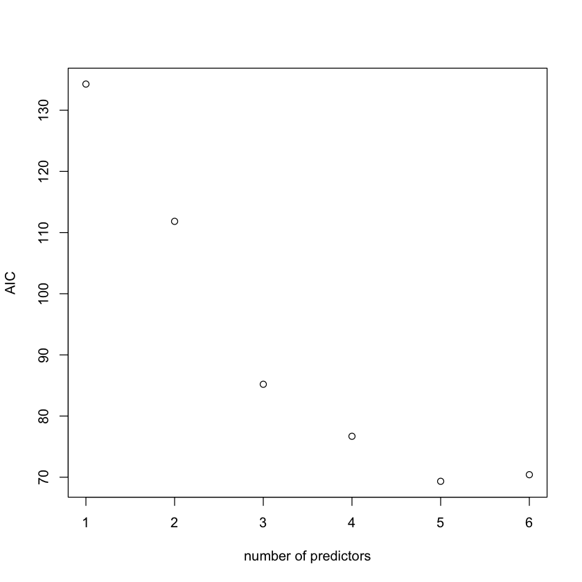

```r
library(leaps)
library(MASS)

n = dim(divorce)[1];
reg_Divorce = regsubsets(divorce ~ .,  data = divorce)
rs_Divorce = summary(reg_Divorce)

AIC = 2*(2:7) + n*log(rs_Divorce$rss/n)
plot(AIC ~ I(1:6), xlab = 'number of predictors', ylab = 'AIC')

lm_divorce = lm(divorce ~ year + femlab + marriage + birth + military, divorce)
```

```r
# Test Cell
```

**B.2 (b) (15 points) Using your model from part (a), compute the variance inflation factors VIFs for each $\widehat\beta_j$, $j = 1,...,p$. Store them in the variable `v`. Also, compute the condition number for the design matrix, stored in `k`. Is there evidence that collinearity causes some predictors not to be significant? Explain your answer.**

```r
library(car) #for the vif() function

v = vif(lm_divorce)
k = kappa(lm_divorce)
v
k
```

**year**

42.9482669472057

**femlab**

48.650934763108

**marriage**

2.62453070971815

**birth**

2.03167683563948

**military**

1.35800179637071

671401.938494793

```r
# Test Cell
```

There is strong evidence of mulit-colinearity between `year` and `femlab`. The condition number is very large ($>> 30$) suggesting colinearity issue. Yes, we have distinct evidence that colinearity is causing some predictors to not be significant.

#### B.2 (c) (10 points) Remove the predictor with the highest VIF. Does that reduce the multicollinearity?

```r
lm_divorce = update(lm_divorce, .~.-femlab)

vif(lm_divorce)
```

**year**

1.83370639925006

**marriage**

2.33192135504646

**birth**

1.98254110704965

**military**

1.12580667212605

The VIF that was assiociated with `year` decreased tremendously (i.e. $VIF<5$), however, I think it reduced multicollinearity but no remove multicollinearity.